# JY-backward

Jingyu Xu

2018/12/9

```r
#load and exculde redundant variable
can_reg = read.csv(file = "./Cancer_Registry.csv")
can_reg_omit = can_reg %>%
  janitor::clean_names() %>%
  select(-pct_some_col18_24, -pct_no_hs18_24, -pct_hs18_24, -pct_bach_deg18_24, -avg_ann_count, -incidence_rate, -avg_deaths_per_year, -med_income, -pop_est2015, -median_age_male, -median_age_female, -percent_married, -pct_employed16_over, -pct_private_coverage, -pct_private_coverage_alone, -pct_emp_priv_coverage, -pct_public_coverage, -pct_black, -pct_asian, -pct_other_race) %>%
  na.omit()%>%
  filter(median_age < 100)%>%
  select(geography, target_death_rate, binned_inc, everything())
```

```r
#description of raw dataset and cleaned dataset
summary(can_reg)
```

```
##   avgAnnCount      avgDeathsPerYear TARGET_deathRate incidenceRate
##  Min.   :    6.0   Min.   :    3    Min.   : 59.7    Min.   : 201.3
##  1st Qu.:   76.0   1st Qu.:   28    1st Qu.:161.2    1st Qu.: 420.3
##  Median :  171.0   Median :   61    Median :178.1    Median : 453.5
##  Mean   :  606.3   Mean   :  186    Mean   :178.7    Mean   : 448.3
##  3rd Qu.:  518.0   3rd Qu.:  149    3rd Qu.:195.2    3rd Qu.: 480.9
##  Max.   :38150.0   Max.   :14010    Max.   :362.8    Max.   :1206.9
##
##    medIncome        popEst2015       povertyPercent   studyPerCap
##  Min.   : 22640   Min.   :     827   Min.   : 3.20   Min.   :   0.00
##  1st Qu.: 38882   1st Qu.:   11684   1st Qu.:12.15   1st Qu.:   0.00
##  Median : 45207   Median :   26643   Median :15.90   Median :   0.00
##  Mean   : 47063   Mean   :  102637   Mean   :16.88   Mean   : 155.40
##  3rd Qu.: 52492   3rd Qu.:   68671   3rd Qu.:20.40   3rd Qu.:  83.65
##  Max.   :125635   Max.   :10170292   Max.   :47.40   Max.   :9762.31
##
##               binnedInc      MedianAge      MedianAgeMale
##  (45201, 48021.6]  : 306   Min.   : 22.30   Min.   :22.40
##  (54545.6, 61494.5]: 306   1st Qu.: 37.70   1st Qu.:36.35
##  [22640, 34218.1]  : 306   Median : 41.00   Median :39.60
##  (42724.4, 45201]  : 305   Mean   : 45.27   Mean   :39.57
##  (48021.6, 51046.4]: 305   3rd Qu.: 44.00   3rd Qu.:42.50
##  (51046.4, 54545.6]: 305   Max.   :624.00   Max.   :64.70
##  (Other)           :1214
##  MedianAgeFemale                            Geography    AvgHouseholdSize
##  Min.   :22.30   Abbeville County, South Carolina:   1   Min.   :0.0221
##  1st Qu.:39.10   Acadia Parish, Louisiana        :   1   1st Qu.:2.3700
##  Median :42.40   Accomack County, Virginia       :   1   Median :2.5000
##  Mean   :42.15   Ada County, Idaho               :   1   Mean   :2.4797
##  3rd Qu.:45.30   Adair County, Iowa              :   1   3rd Qu.:2.6300
##  Max.   :65.70   Adair County, Kentucky          :   1   Max.   :3.9700
##                  (Other)                         :3041
##  PercentMarried   PctNoHS18_24     PctHS18_24   PctSomeCol18_24
##  Min.   :23.10   Min.   : 0.00   Min.   : 0.0   Min.   : 7.10
##  1st Qu.:47.75   1st Qu.:12.80   1st Qu.:29.2   1st Qu.:34.00
##  Median :52.40   Median :17.10   Median :34.7   Median :40.40
##  Mean   :51.77   Mean   :18.22   Mean   :35.0   Mean   :40.98
##  3rd Qu.:56.40   3rd Qu.:22.70   3rd Qu.:40.7   3rd Qu.:46.40
##  Max.   :72.50   Max.   :64.10   Max.   :72.5   Max.   :79.00
##                                                 NA's   :2285
```

[output cut: 25 more lines]

```
##  Min.   : 10.20   Min.   : 0.0000   Min.   : 0.0000   Min.   : 0.0000
##  1st Qu.: 77.30   1st Qu.: 0.6207   1st Qu.: 0.2542   1st Qu.: 0.2952
##  Median : 90.06   Median : 2.2476   Median : 0.5498   Median : 0.8262
##  Mean   : 83.65   Mean   : 9.1080   Mean   : 1.2540   Mean   : 1.9835
##  3rd Qu.: 95.45   3rd Qu.:10.5097   3rd Qu.: 1.2210   3rd Qu.: 2.1780
##  Max.   :100.00   Max.   :85.9478   Max.   :42.6194   Max.   :41.9303
##
##  PctMarriedHouseholds   BirthRate
##  Min.   :22.99        Min.   : 0.000
##  1st Qu.:47.76        1st Qu.: 4.521
##  Median :51.67        Median : 5.381
##  Mean   :51.24        Mean   : 5.640
##  3rd Qu.:55.40        3rd Qu.: 6.494
##  Max.   :78.08        Max.   :21.326
##
```

```r
summary(can_reg_omit)
```

```
##                             geography    target_death_rate
##  Abbeville County, South Carolina:   1   Min.   : 59.7
##  Acadia Parish, Louisiana        :   1   1st Qu.:161.3
##  Accomack County, Virginia       :   1   Median :178.1
##  Ada County, Idaho               :   1   Mean   :178.6
##  Adair County, Iowa              :   1   3rd Qu.:195.2
##  Adair County, Kentucky          :   1   Max.   :362.8
##  (Other)                         :3011
##               binned_inc   poverty_percent study_per_cap
##  (51046.4, 54545.6]: 304   Min.   : 3.20   Min.   :   0.0
##  [22640, 34218.1]  : 304   1st Qu.:12.20   1st Qu.:   0.0
##  (42724.4, 45201]  : 303   Median :15.80   Median :   0.0
##  (45201, 48021.6]  : 303   Mean   :16.88   Mean   : 156.6
##  (48021.6, 51046.4]: 303   3rd Qu.:20.40   3rd Qu.:  83.9
##  (54545.6, 61494.5]: 302   Max.   :47.40   Max.   :9762.3
##  (Other)           :1198
##    median_age    avg_household_size pct_hs25_over   pct_bach_deg25_over
##  Min.   :22.30   Min.   :0.0221     Min.   : 7.50   Min.   : 2.50
##  1st Qu.:37.70   1st Qu.:2.3700     1st Qu.:30.40   1st Qu.: 9.40
##  Median :40.90   Median :2.5000     Median :35.30   Median :12.30
##  Mean   :40.82   Mean   :2.4790     Mean   :34.81   Mean   :13.28
##  3rd Qu.:43.80   3rd Qu.:2.6300     3rd Qu.:39.70   3rd Qu.:16.10
##  Max.   :65.30   Max.   :3.9700     Max.   :54.80   Max.   :42.20
##
##  pct_unemployed16_over pct_public_coverage_alone   pct_white
##  Min.   : 0.400        Min.   : 2.60             Min.   : 10.20
##  1st Qu.: 5.500        1st Qu.:14.80             1st Qu.: 77.40
##  Median : 7.600        Median :18.80             Median : 90.06
##  Mean   : 7.839        Mean   :19.24             Mean   : 83.67
##  3rd Qu.: 9.700        3rd Qu.:23.10             3rd Qu.: 95.44
##  Max.   :29.400        Max.   :46.60             Max.   :100.00
##
##  pct_married_households   birth_rate
##  Min.   :22.99          Min.   : 0.000
##  1st Qu.:47.78          1st Qu.: 4.525
##  Median :51.68          Median : 5.381
##  Mean   :51.25          Mean   : 5.639
##  3rd Qu.:55.40          3rd Qu.: 6.492
##  Max.   :78.08          Max.   :21.326
##
```

## Backward elimination (AIC based)

```r
#backward elimination
 can_reg_back = can_reg_omit%>%
  select(-geography)

initial_fit = lm(target_death_rate~., data = can_reg_back)
step(initial_fit, direction = "backward")
```

```
## Start:  AIC=18758.76
## target_death_rate ~ binned_inc + poverty_percent + study_per_cap +
##     median_age + avg_household_size + pct_hs25_over + pct_bach_deg25_over +
##     pct_unemployed16_over + pct_public_coverage_alone + pct_white +
##     pct_married_households + birth_rate
##
##                             Df Sum of Sq     RSS   AIC
## - pct_white                  1       803 1493036 18758
## - poverty_percent            1       827 1493060 18758
## <none>                                   1492233 18759
## - study_per_cap              1      1352 1493584 18760
## - avg_household_size         1      2847 1495080 18762
## - pct_public_coverage_alone  1      5469 1497702 18768
## - binned_inc                 9     19007 1511240 18779
## - birth_rate                 1     16249 1508482 18789
## - median_age                 1     16663 1508896 18790
## - pct_unemployed16_over      1     18651 1510884 18794
## - pct_bach_deg25_over        1     22652 1514885 18802
## - pct_married_households     1     28821 1521054 18814
## - pct_hs25_over              1     57806 1550039 18871
##
## Step:  AIC=18758.39
## target_death_rate ~ binned_inc + poverty_percent + study_per_cap +
##     median_age + avg_household_size + pct_hs25_over + pct_bach_deg25_over +
##     pct_unemployed16_over + pct_public_coverage_alone + pct_married_households +
##     birth_rate
##
##                             Df Sum of Sq     RSS   AIC
## <none>                                   1493036 18758
## - poverty_percent            1      1174 1494210 18759
## - study_per_cap              1      1474 1494511 18759
## - avg_household_size         1      3262 1496299 18763
## - pct_public_coverage_alone  1      5694 1498730 18768
## - binned_inc                 9     18252 1511288 18777
## - median_age                 1     16080 1509116 18789
## - birth_rate                 1     16877 1509914 18790
## - pct_unemployed16_over      1     17854 1510890 18792
## - pct_bach_deg25_over        1     22239 1515275 18801
## - pct_married_households     1     30263 1523299 18817
## - pct_hs25_over              1     59325 1552361 18874
```

```
##
## Call:
## lm(formula = target_death_rate ~ binned_inc + poverty_percent +
##     study_per_cap + median_age + avg_household_size + pct_hs25_over +
##     pct_bach_deg25_over + pct_unemployed16_over + pct_public_coverage_alone +
##     pct_married_households + birth_rate, data = can_reg_back)
##
## Coefficients:
##                  (Intercept)  binned_inc(37413.8, 40362.7]
##                   219.043802                     -1.394604
## binned_inc(40362.7, 42724.4]    binned_inc(42724.4, 45201]
##                    -3.561961                     -4.233303
##   binned_inc(45201, 48021.6]  binned_inc(48021.6, 51046.4]
##                    -4.349586                     -7.179177
## binned_inc(51046.4, 54545.6]  binned_inc(54545.6, 61494.5]
##                    -5.189801                     -4.724600
##  binned_inc(61494.5, 125635]    binned_inc[22640, 34218.1]
##                     0.409637                      3.335973
##              poverty_percent                 study_per_cap
##                    -0.281601                      0.001331
##                   median_age            avg_household_size
##                    -0.582798                     -2.721163
##                pct_hs25_over           pct_bach_deg25_over
##                     1.059885                     -1.047613
##        pct_unemployed16_over     pct_public_coverage_alone
##                     1.026085                      0.435298
##       pct_married_households                    birth_rate
##                    -0.684372                     -1.230799
```

After backward elimination, the final model is : target_death_rate ~ binned_inc + poverty_percent + study_per_cap + median_age + avg_household_size + pct_hs25_over + pct_bach_deg25_over + pct_unemployed16_over + pct_public_coverage_alone + pct_married_households + birth_rate

There are 11 variables in the model.

## Check the distribution of variables

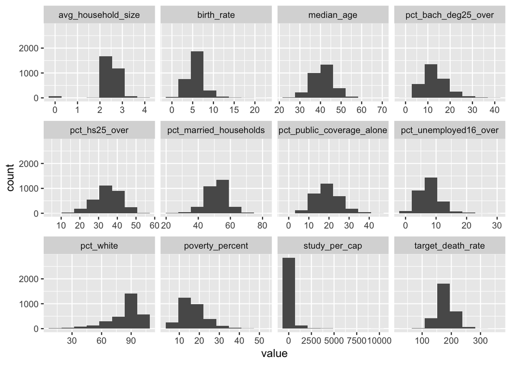

```r
##see the distribution of each variables

ggplot(gather(select(can_reg_back, -binned_inc)), aes(value)) +
    geom_histogram(bins = 8) +
    facet_wrap(~key, scales = 'free_x')
```

pct_white, poverty_percent and study_per_cap are a little skewed, other variables are nearly symmetric

## Model diagnosis

```r
##summary of final model
back_model = lm(formula = target_death_rate ~ binned_inc + poverty_percent +
    study_per_cap + median_age + avg_household_size + pct_hs25_over +
    pct_bach_deg25_over + pct_unemployed16_over + pct_public_coverage_alone +
    pct_married_households + birth_rate, data = can_reg_back)

summary(back_model)
```

```
##
## Call:
## lm(formula = target_death_rate ~ binned_inc + poverty_percent +
##     study_per_cap + median_age + avg_household_size + pct_hs25_over +
##     pct_bach_deg25_over + pct_unemployed16_over + pct_public_coverage_alone +
##     pct_married_households + birth_rate, data = can_reg_back)
##
## Residuals:
##      Min       1Q   Median       3Q      Max
## -104.215  -12.230    0.433   12.078  165.654
##
## Coefficients:
##                                Estimate Std. Error t value Pr(>|t|)
## (Intercept)                   2.190e+02  1.078e+01  20.328  < 2e-16 ***
## binned_inc(37413.8, 40362.7] -1.395e+00  1.874e+00  -0.744 0.456863
## binned_inc(40362.7, 42724.4] -3.562e+00  1.954e+00  -1.823 0.068477 .
## binned_inc(42724.4, 45201]   -4.233e+00  2.064e+00  -2.051 0.040349 *
## binned_inc(45201, 48021.6]   -4.350e+00  2.187e+00  -1.989 0.046839 *
## binned_inc(48021.6, 51046.4] -7.179e+00  2.334e+00  -3.076 0.002119 **
## binned_inc(51046.4, 54545.6] -5.190e+00  2.457e+00  -2.112 0.034782 *
## binned_inc(54545.6, 61494.5] -4.725e+00  2.649e+00  -1.783 0.074654 .
## binned_inc(61494.5, 125635]   4.096e-01  3.158e+00   0.130 0.896791
## binned_inc[22640, 34218.1]    3.336e+00  1.993e+00   1.674 0.094290 .
## poverty_percent              -2.816e-01  1.835e-01  -1.535 0.124894
## study_per_cap                 1.332e-03  7.739e-04   1.720 0.085474 .
## median_age                   -5.828e-01  1.026e-01  -5.681 1.46e-08 ***
## avg_household_size           -2.721e+00  1.063e+00  -2.559 0.010544 *
## pct_hs25_over                 1.060e+00  9.712e-02  10.913  < 2e-16 ***
## pct_bach_deg25_over          -1.048e+00  1.568e-01  -6.681 2.81e-11 ***
## pct_unemployed16_over         1.026e+00  1.714e-01   5.986 2.40e-09 ***
## pct_public_coverage_alone     4.353e-01  1.288e-01   3.381 0.000732 ***
## pct_married_households       -6.844e-01  8.781e-02  -7.794 8.88e-15 ***
## birth_rate                   -1.231e+00  2.115e-01  -5.821 6.49e-09 ***
## ---
## Signif. codes:  0 '***' 0.001 '**' 0.01 '*' 0.05 '.' 0.1 ' ' 1
##
## Residual standard error: 22.32 on 2997 degrees of freedom
## Multiple R-squared:  0.3565, Adjusted R-squared:  0.3525
## F-statistic:  87.4 on 19 and 2997 DF,  p-value: < 2.2e-16
```

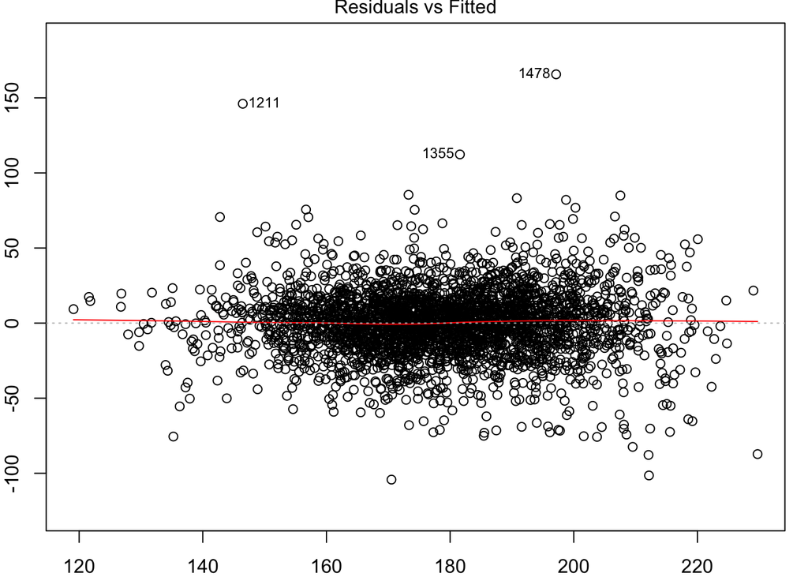

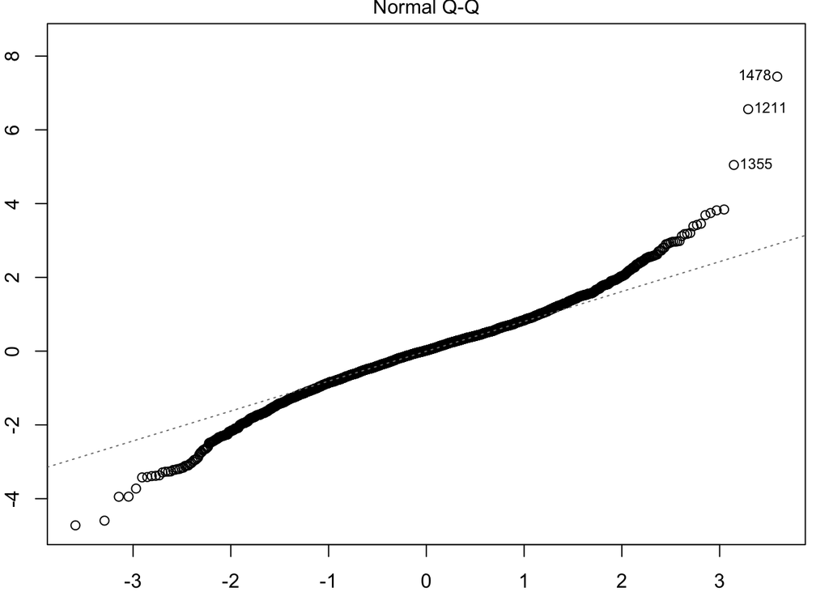

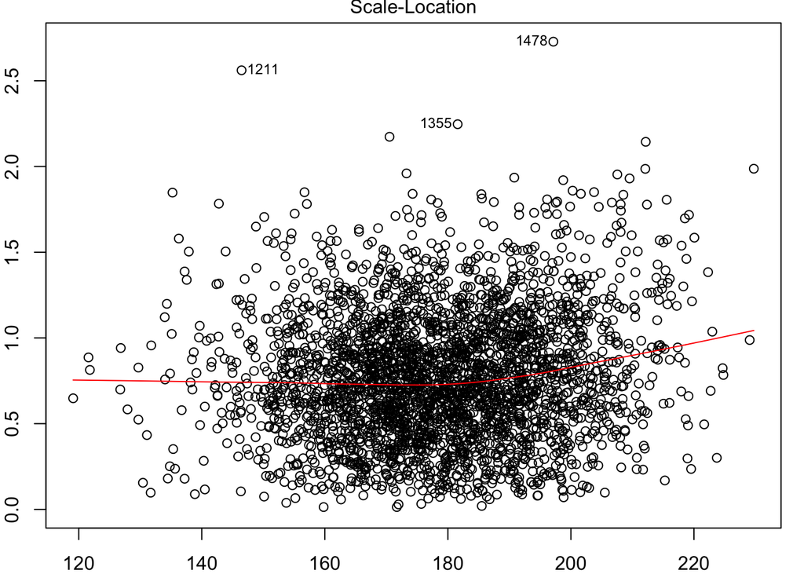

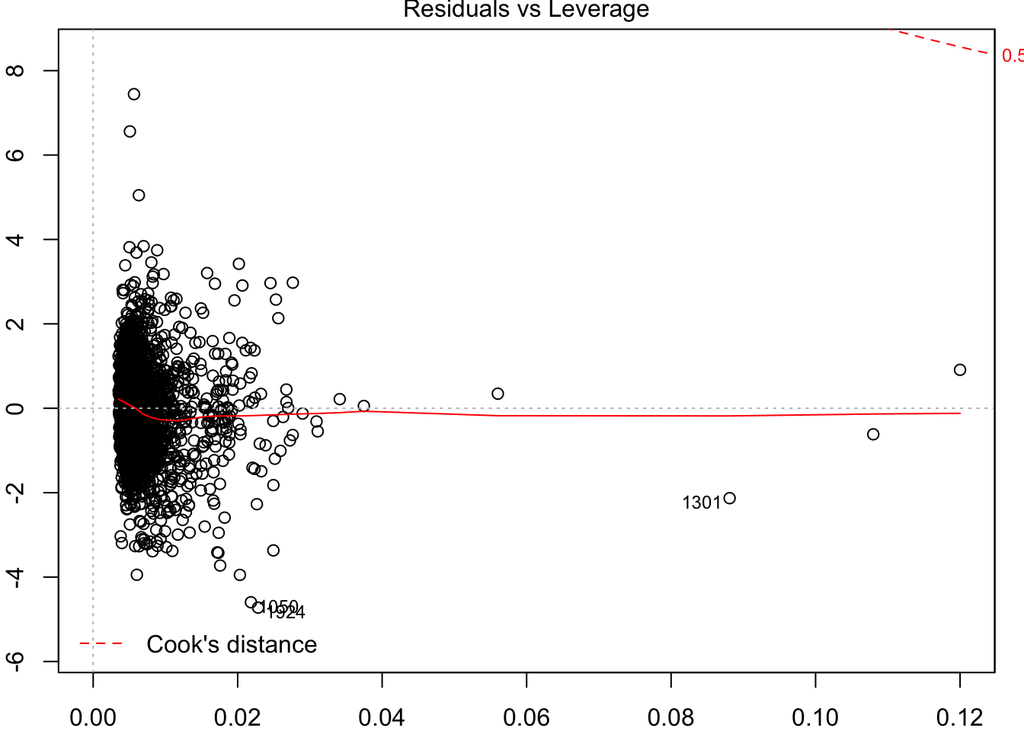

```r
par(mar=c(2,2,1,1))
plot(back_model)
```

- From residual and scale location figure, I found the points distributed evenly around the horizontal line, indicating the constant variance
- From QQ plot, we can observe a tail deviating from normal, which doubts the normality of residuals.
- From Residual and Leverage plot, we observe the potential outlier: 1050, 1924 and 1301
- The global F-statistic is 87.4， indicating the linear relationship between the outcome and the covariates is significant. However， there are still covariates that are insignifficant and the adjusted R square is low (0.3525).

*Further modificaton may be needed